# Weather_change

first I used (select* from global_data;)for all three to extract the data

Here I imported pandas and matplotlib

```python
import pandas as p
import matplotlib.pyplot as plt
%matplotlib inline
```

I read my city_data.csv file and printed it...

```python
a= p.read_csv('city_data.csv' )
```

```python
print(a)
```

```
             city               country
0         Abidjan         Côte D'Ivoire
1       Abu Dhabi  United Arab Emirates
2           Abuja               Nigeria
3           Accra                 Ghana
4           Adana                Turkey
..            ...                   ...
337        Xuzhou                 China
338  Yamoussoukro         Côte D'Ivoire
339       Yerevan               Armenia
340        Zagreb               Croatia
341       Zapopan                Mexico

[342 rows x 2 columns]
```

I read my city_list.csv file and printed it...

```python
b=p.read_csv('city_list.csv' )
```

```python
print(b)
```

```
       year     city        country  avg_temp
0      1849  Abidjan  Côte D'Ivoire     25.58
1      1850  Abidjan  Côte D'Ivoire     25.52
2      1851  Abidjan  Côte D'Ivoire     25.67
3      1852  Abidjan  Côte D'Ivoire       NaN
4      1853  Abidjan  Côte D'Ivoire       NaN
...     ...      ...            ...       ...
70787  2009  Zapopan         Mexico     21.76
70788  2010  Zapopan         Mexico     20.90
70789  2011  Zapopan         Mexico     21.55
70790  2012  Zapopan         Mexico     21.52
70791  2013  Zapopan         Mexico     22.19

[70792 rows x 4 columns]
```

I read my global_data.csv file and printed it...

```python
c=p.read_csv('global_data.csv' )
```

```python
print(c)
```

```
     year  avg_temp
0    1750      8.72
1    1751      7.98
2    1752      5.78
3    1753      8.39
4    1754      8.47
..    ...       ...
261  2011      9.52
262  2012      9.51
263  2013      9.61
264  2014      9.57
265  2015      9.83

[266 rows x 2 columns]
```

I am searching for fimiliar countries

```python
a[a.country.isin(['Switzerland'])]
```

|  | city | country |
| --- | --- | --- |
| 43 | Bern | Switzerland |

```python
choice=input('about what counry??')
a[a.country.isin([choice])]
```

```
about what counry??United States
```

|  | city | country |
| --- | --- | --- |
| 8 | Albuquerque | United States |
| 10 | Alexandria | United States |
| 19 | Arlington | United States |
| 23 | Atlanta | United States |
| 24 | Austin | United States |
| 27 | Baltimore | United States |
| 46 | Birmingham | United States |
| 48 | Boston | United States |
| 66 | Charlotte | United States |
| 69 | Chicago | United States |
| 73 | Colorado Springs | United States |
| 74 | Columbus | United States |
| 81 | Dallas | United States |
| 86 | Denver | United States |
| 87 | Detroit | United States |
| 96 | El Paso | United States |
| 98 | Fort Worth | United States |
| 102 | Fresno | United States |
| 124 | Houston | United States |
| 128 | Indianapolis | United States |
| 134 | Jacksonville | United States |
| 146 | Kansas City | United States |
| 167 | Las Vegas | United States |
| 175 | Long Beach | United States |
| 177 | Los Angeles | United States |
| 178 | Louisville | United States |
| 198 | Memphis | United States |
| 199 | Mesa | United States |
| 201 | Miami | United States |
| 203 | Milwaukee | United States |
| 204 | Minneapolis | United States |
| 220 | Nashville | United States |
| 223 | New Orleans | United States |
| 224 | New York | United States |
| 228 | Oakland | United States |
| 229 | Oklahoma City | United States |
| 230 | Omaha | United States |
| 242 | Philadelphia | United States |
| 243 | Phoenix | United States |
| 249 | Portland | United States |
| 261 | Raleigh | United States |
| 270 | Sacramento | United States |
| 273 | San Antonio | United States |
| 274 | San Diego | United States |
| 275 | San Francisco | United States |
| 276 | San Jose | United States |
| 285 | Seattle | United States |
| 314 | Tucson | United States |
| 315 | Tulsa | United States |
| 327 | Virginia Beach | United States |
| 330 | Washington | United States |
| 332 | Wichita | United States |

I decided to take New Dehli

```python
a[a.city.isin(['New Delhi'])]
```

|  | city | country |
| --- | --- | --- |
| 222 | New Delhi | India |

collected all Data from New Dehli the city_list.csv that I assined to b

```python
new_dehli=b[b.city.isin(['New Delhi'])]
print(new_dehli)
```

```
       year       city country  avg_temp
45694  1796  New Delhi   India     25.03
45695  1797  New Delhi   India     26.71
45696  1798  New Delhi   India     24.29
45697  1799  New Delhi   India     25.28
45698  1800  New Delhi   India     25.21
...     ...        ...     ...       ...
45907  2009  New Delhi   India     26.55
45908  2010  New Delhi   India     26.52
45909  2011  New Delhi   India     25.63
45910  2012  New Delhi   India     25.89
45911  2013  New Delhi   India     26.71

[218 rows x 4 columns]
```

Here I ploted the average Temperature in New Dehli and you can see that the blue line is sometimes skipping over and that is for the Data that I did not get(NaN)

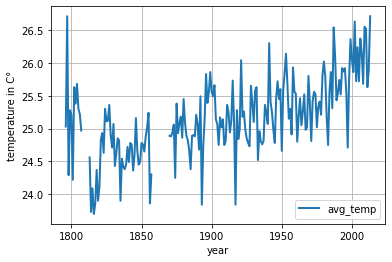

```python
first=new_dehli.plot('year','avg_temp',grid=True,LineWidth=2)

plt.ylabel('temperature in C°')
plt.xlabel('year')
```

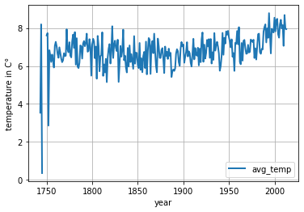

```python
s=b[b.city.isin(['Bern'])]

s.plot('year','avg_temp',grid=True,LineWidth=2)
plt.ylabel('temperature in C°')
plt.xlabel('year')
```

This is the average Temerature on the hole planet

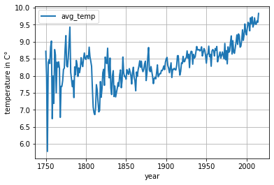

```python
second=c.plot('year','avg_temp',grid=True,LineWidth=2)

plt.ylabel('temperature in C°')
plt.xlabel('year')
```

If you take the temperature range from o to 28 degrees c° the change does not seem visible anymore since the range is biiger but the numbers are the same and this is how you can fool somebody with satistics and at the same time prove a point.This oly proves the power of satistics.I did this to be able to compare the temperatures.

```
1)India,New Dehli:
2)Switzerland,Bern:
3)total average:
```

```
[1980, 2009, 0, 28]
```

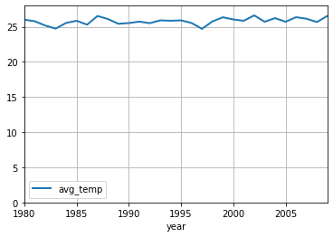

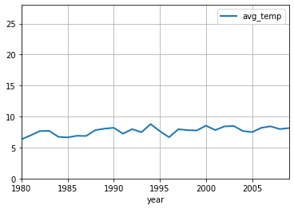

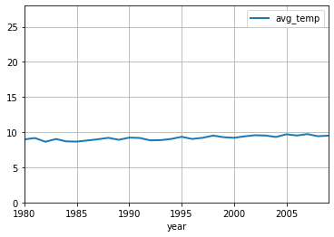

```python
print('1)India,New Dehli:')
first=new_dehli.plot('year','avg_temp',grid=True,LineWidth=2)
plt.axis([1980, 2009,0,28])
print('2)Switzerland,Bern:')
s.plot('year','avg_temp',grid=True,LineWidth=2)
plt.axis([1980, 2009,0,28])
print('3)total average:')
second=c.plot('year','avg_temp',grid=True,LineWidth=2)
plt.axis([1980, 2009,0,28])
```

Here I created the moving avarge.You ca put in how accurate you want it to be and than press enter.

```
how exact do whant your moving avarage plot to be?(265 years)240
```

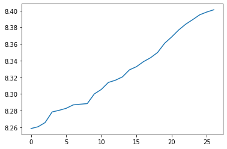

```python
numbers = c.avg_temp
window_size = int(input("how exact do whant your moving avarage plot to be?(265 years)"))

i = 0
moving_averages = []
while i < len(numbers) - window_size + 1:
    this_window = numbers[i : i + window_size]


    window_average = sum(this_window) / window_size
    moving_averages.append(window_average)
    i += 1

plt.plot(moving_averages)
#plt.axis([1980, 2009,0,10])
```

-We can clearly see that the earth is getting warmer. -It is visible that New Dehli is warmer than the averge Temperature -Bern,Swizerland is colder than the average temperature -and that is was very warm durinf the industrial times and that it went down from thaere and than it came back higher than ever

Thank you for your time --Simi